# Evaluate Imputation Performance

```r
knitr::opts_knit$set(root.dir = normalizePath(".."))
```

## Using Old Perturbation Signatures

### Performance on CTRPv2

Get all necessary imports and functions

```r
rm(list=ls())
set.seed(9833)
library(ROCR)
library(reshape2)
library(caret)
library(SNFtool)
library(org.Hs.eg.db)
source("RCode/flexible_layers/sensitivityDataFlexible.R")
source("RCode/flexible_layers/perturbationDataFlexible.R")
source("RCode/flexible_layers/perturbationDataFlexibleCustomSig.R")
source("RCode/flexible_layers/structureDataFlexible.R")
source("RCode/flexible_layers/imagingDataFlexible.R")
source("RCode/flexible_layers/constImagingLayerFlexible.R")
source("RCode/flexible_layers/constSensitivityLayerFlexible.R")
source("RCode/flexible_layers/constPerturbationLayerFlexible.R")
source("RCode/flexible_layers/constStructureLayerFlexible.R")
source("RCode/cindexComp2.R")
source("RCode/flexible_layers/compConcordIndxFlexible.R")
source("RCode/flexible_layers/generateDrugPairsFlexible.R")
source("RCode/flexible_layers/drugTargetBenchFlexible.R")
source("RCode/flexible_layers/compDrugTargetBenchmarkFlexible.R")
source("RCode/flexible_layers/stackedLayerAnalysisHelpers.R")
source("RCode/flexible_layers/printCIndices.R")
source("RCode/flexible_layers/printPVals.R")
source("RCode/flexible_layers/generateROCPlotFlexible.R")
source("RCode/predPerf.R")
source("RCode/value_inference_models/modifying_snf/snfModifiedHelpers.R")
badchars <- "[\xb5]|[\n]|[,]|[;]|[:]|[-]|[+]|[*]|[%]|[$]|[#]|[{]|[}]|[[]|[]]|[|]|[\\^]|[/]|[\\]|[.]|[_]|[ ]"
```

Load LINCS metadata file. Used it contains the smiles string for the drugs in the perturbation layer. These are then used to construct the structure layer.

```r
lincs.meta <- read.csv("Data/LINCS.csv", stringsAsFactors = FALSE)
lincs.meta$pert_iname <- toupper(lincs.meta$pert_iname)
lincs.meta$pert_iname <- gsub(badchars, "", lincs.meta$pert_iname)
```

Load in senstivity, imaging data as well as perturbation signatures

```r
pert.file.name <- "Data/L1000_compound_signatures.RData"
sensitivity.file.name <- "Data/combined_sensitivity//combined_sens_iname_replaced.RData"
imaging.file.name <- "Data/imaging_processed/imaging_subsetted_normalized_pca.RData"
sens.data <- SensitivityDataFlexible(sensitivity.file.name)  ## 645 X 239
pert.data <- PerturbationDataFlexible(pert.file.name, lincs.meta)  ## 978 X 23
imaging.data <- ImagingDataFlexible(badchars)
imaging.data <- imaging.data[, colnames(imaging.data) %in% colnames(sens.data)]
```

Subset the lincs metadata file to only the drugs appearing in the sensitivity layer

```r
sens.names <- rownames(sens.data)
lincs.meta.subset <- lincs.meta[match(sens.names, lincs.meta$pert_iname),]
lincs.meta.subset <- lincs.meta.subset[!is.na(lincs.meta.subset$X),]
```

Now we create the structure fingerprints based on the subsetted lincs metadata

```r
strc.data <- StructureDataFlexible(lincs.meta.subset)  ## a vector  --> 239 elemnts
```

Now we can choose the layers to be used in the integration and see the drugs that are common between them

```r
layers <- list(sens.names = sort(colnames(sens.data)), pert.names=colnames(pert.data),
               strc.names = names(strc.data))
common.drugs <- Reduce(intersect, Filter(Negate(is.null),layers))
print(length(common.drugs))
```

```
[1] 365
```

At this point we have all the data necessary to create the various similarity matrices. Keep in mind that in the case of the senstivity layer, the data loaded in is already a similarity matrix, so there is nothing to do there. Note that we are leaving out the perturbation layer since that is the one that we are evaluating the effect of imputation on.

```r
strc.cor <- fingerprint::fp.sim.matrix(strc.data, method = "tanimoto")
colnames(strc.cor) <- names(strc.data)
rownames(strc.cor) <- names(strc.data)
imaging.cor <- ConstImagingLayerFlexible(imaging.data)
sens.cor <- sens.data[common.drugs, common.drugs]
```

To impute drugs that are actually relevant to the benchmark, we need to obtain the drugs that would actually be used in the benchmark.

```r
benchmark.drugs <- DrugTargetBenchFlexible(common.drugs, gmt_file_name="temp", use.ctrpv2=TRUE,
                        use.clue=FALSE, use.chembl=FALSE, use.dbank=FALSE, use.dtc=FALSE)
benchmark.drugs <- colnames(benchmark.drugs)
```

```r
set.seed(981)
imputation.sizes <- c(0, 10, 25, 50, 100, length(benchmark.drugs))
subsetted.pert.cor <- list()
subsetted.sens.cor <- list()
subsetted.strc.cor <- list()
for (i in imputation.sizes) {
    drugs.to.remove <- sample(1:length(benchmark.drugs), i)
    drugs.to.remove <- benchmark.drugs[drugs.to.remove]

    temp.pert <- pert.data[, common.drugs]
    temp.pert <- temp.pert[, !(colnames(temp.pert) %in% drugs.to.remove)]
    subsetted.pert.cor[[as.character(i)]] <- cor(temp.pert, method="pearson", use="pairwise.complete.obs")

    temp.sens <- sens.data[common.drugs, common.drugs]
    temp.sens <- temp.sens[!(rownames(temp.sens) %in% drugs.to.remove), !(colnames(temp.sens) %in% drugs.to.remove)]
    subsetted.sens.cor[[as.character(i)]] <- temp.sens

    temp.strc <- strc.data[common.drugs]
    temp.strc <- temp.strc[!(names(temp.strc) %in% drugs.to.remove)]
    temp.names <- names(temp.strc)
    temp.strc <- fingerprint::fp.sim.matrix(temp.strc, method = "tanimoto")
    colnames(temp.strc) <- temp.names
    rownames(temp.strc) <- temp.names
    subsetted.strc.cor[[as.character(i)]] <- temp.strc
}
```

```r
all.drugs <- common.drugs
```

#### Perturbation Imputation Effect

Now we loop over the various subsetted perturbation data versions and evaluate the performance of imputing the drugs that are intentionally missing.

```
[1] "Benchmark obtained"
[1] "Drug pairs obtained"
[1] "Concordance Index computed"
c.indices values from each layer vs. the benchmark:
strcCindex: 0.6964124
sensCindex: 0.8837202
pertCindex: 0.6428657
integrCindex: 0.9200923
p-vals from the c.index comparison of integration layer vs.
strcPVal: 9.025341e-58
sensPVal: 0.0004656051
pertPVal: 1.118052e-69
[1] "Benchmark obtained"
[1] "Drug pairs obtained"
[1] "Concordance Index computed"
c.indices values from each layer vs. the benchmark:
strcCindex: 0.6964124
sensCindex: 0.8837202
pertCindex: 0.688187
integrCindex: 0.9267418
p-vals from the c.index comparison of integration layer vs.
strcPVal: 1.961845e-61
sensPVal: 3.441377e-05
pertPVal: 2.506046e-48
```

```
[1] "Benchmark obtained"
[1] "Drug pairs obtained"
[1] "Concordance Index computed"
c.indices values from each layer vs. the benchmark:
strcCindex: 0.6964124
sensCindex: 0.8837202
pertCindex: 0.7205642
integrCindex: 0.9284236
p-vals from the c.index comparison of integration layer vs.
strcPVal: 4.915441e-62
sensPVal: 1.118054e-05
pertPVal: 9.797633e-39
```

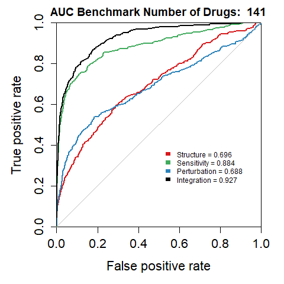

```
[1] "Benchmark obtained"
[1] "Drug pairs obtained"
[1] "Concordance Index computed"
c.indices values from each layer vs. the benchmark:
strcCindex: 0.6964124
sensCindex: 0.8837202
pertCindex: 0.7838191
integrCindex: 0.9323513
p-vals from the c.index comparison of integration layer vs.
strcPVal: 1.33337e-65
sensPVal: 1.432153e-06
pertPVal: 5.888214e-24
```

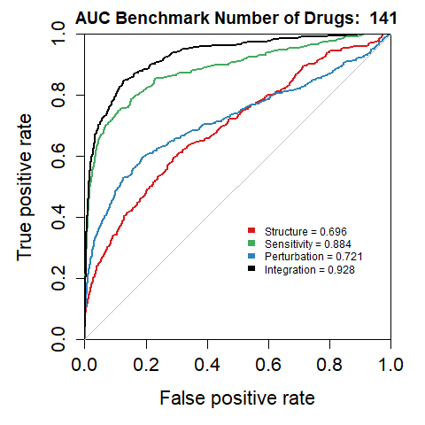

```
[1] "Benchmark obtained"
[1] "Drug pairs obtained"
[1] "Concordance Index computed"
c.indices values from each layer vs. the benchmark:
strcCindex: 0.6964124
sensCindex: 0.8837202
pertCindex: 0.8716431
integrCindex: 0.9312892
p-vals from the c.index comparison of integration layer vs.
strcPVal: 1.854584e-66
sensPVal: 1.966142e-06
pertPVal: 4.992779e-11
```

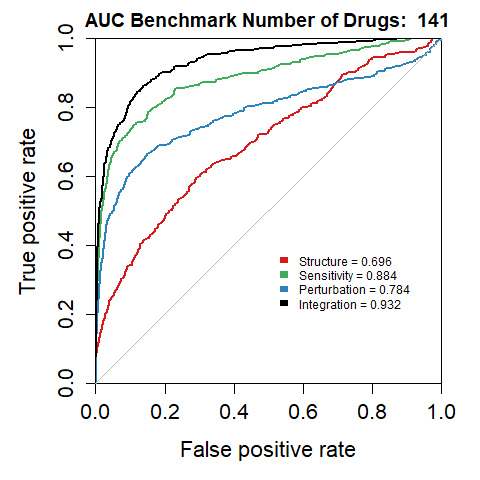

```
[1] "Benchmark obtained"
[1] "Drug pairs obtained"
[1] "Concordance Index computed"
c.indices values from each layer vs. the benchmark:
strcCindex: 0.6964124
sensCindex: 0.8837202
pertCindex: 0.8931913
integrCindex: 0.932598
p-vals from the c.index comparison of integration layer vs.
strcPVal: 9.028276e-67
sensPVal: 6.119256e-07
pertPVal: 7.846583e-08
```

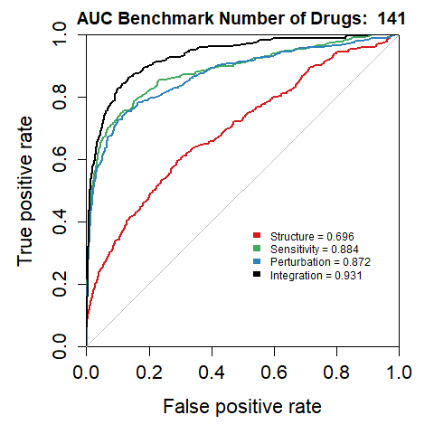

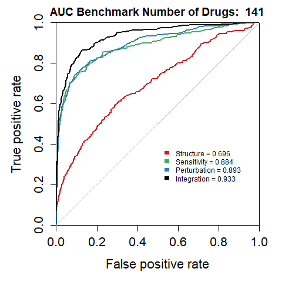

```r
for (i in imputation.sizes) {
    pert.cor <- subsetted.pert.cor[[as.character(i)]]
    sens.cor <- subsetted.sens.cor[["0"]]
    strc.cor <- subsetted.strc.cor[["0"]]

    correlation.matrices <- list(sens=sens.cor, pert=pert.cor, strc=strc.cor)

    augmented.matrices <- CreateAugmentedMatrixSkeletons(names(correlation.matrices), all.drugs)
    augmented.matrices <- ReplaceAugmentedExistingValues(augmented.matrices, correlation.matrices)
    affinity.matrices <- CreateAffinityMatrices(augmented.matrices)
    affinity.matrices <- ReplaceAffinityMatrixValuesFast(affinity.matrices, correlation.matrices, all.drugs)

    integrated <- SNFtool::SNF(affinity.matrices)
    rownames(integrated) <- all.drugs
    colnames(integrated) <- all.drugs

    paste("-----Evaluating Performance on ", i, "imputed drugs-----", sep=" ")

    CompDrugTargetBenchmarkFlexible(common.drugs=common.drugs, gmt.file.name="temp",
                                    strc.aff.mat=affinity.matrices$strc,
                                    sens.aff.mat=affinity.matrices$sens, pert.aff.mat=affinity.matrices$pert,
                                    integration=integrated, luminex.aff.mat=NULL,
                                    imaging.aff.mat=NULL, target.roc.file.name="blessed_roc.pdf",
                                    use.ctrpv2=TRUE, use.clue=FALSE, use.chembl=FALSE,
                                    use.dbank=FALSE, use.dtc=FALSE)
}
```

#### Senstivity Imputation Effect

Now we loop over the various subsetted sensitivity data versions and evaluate the performance of imputing the drugs that are intentionally missing.

```
[1] "Benchmark obtained"
[1] "Drug pairs obtained"
[1] "Concordance Index computed"
c.indices values from each layer vs. the benchmark:
strcCindex: 0.6964124
sensCindex: 0.8837202
pertCindex: 0.6428657
integrCindex: 0.9200923
p-vals from the c.index comparison of integration layer vs.
strcPVal: 9.025341e-58
sensPVal: 0.0004656051
pertPVal: 1.118052e-69
[1] "Benchmark obtained"
[1] "Drug pairs obtained"
[1] "Concordance Index computed"
c.indices values from each layer vs. the benchmark:
strcCindex: 0.6964124
sensCindex: 0.8546885
pertCindex: 0.6428657
integrCindex: 0.8963471
p-vals from the c.index comparison of integration layer vs.
strcPVal: 3.634208e-46
sensPVal: 0.0001310177
pertPVal: 6.883066e-59
```

```
[1] "Benchmark obtained"
[1] "Drug pairs obtained"
[1] "Concordance Index computed"
c.indices values from each layer vs. the benchmark:
strcCindex: 0.6964124
sensCindex: 0.8369779
pertCindex: 0.6428657
integrCindex: 0.8849103
p-vals from the c.index comparison of integration layer vs.
strcPVal: 7.354956e-41
sensPVal: 2.856019e-05
pertPVal: 1.688937e-54
```

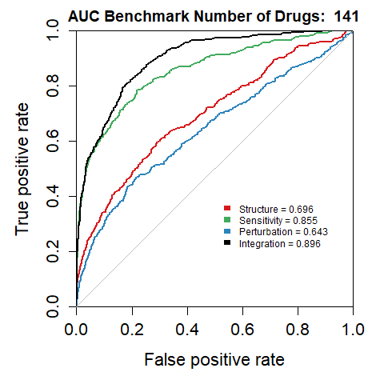

```
[1] "Benchmark obtained"
[1] "Drug pairs obtained"
[1] "Concordance Index computed"
c.indices values from each layer vs. the benchmark:
strcCindex: 0.6964124
sensCindex: 0.7965415
pertCindex: 0.6428657
integrCindex: 0.8352214
p-vals from the c.index comparison of integration layer vs.
strcPVal: 1.689017e-22
sensPVal: 0.0004301031
pertPVal: 4.129549e-35
```

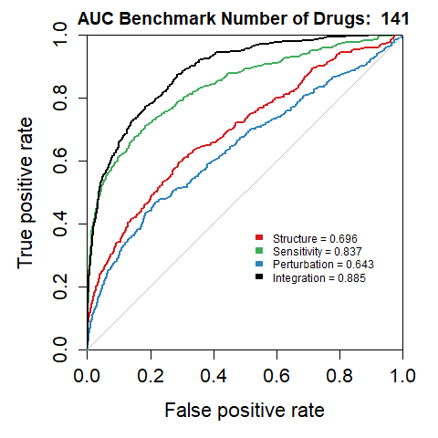

```
[1] "Benchmark obtained"
[1] "Drug pairs obtained"
[1] "Concordance Index computed"
c.indices values from each layer vs. the benchmark:
strcCindex: 0.6964124
sensCindex: 0.742315
pertCindex: 0.6428657
integrCindex: 0.7808996
p-vals from the c.index comparison of integration layer vs.
strcPVal: 4.858263e-09
sensPVal: 0.000365205
pertPVal: 2.198839e-19
```

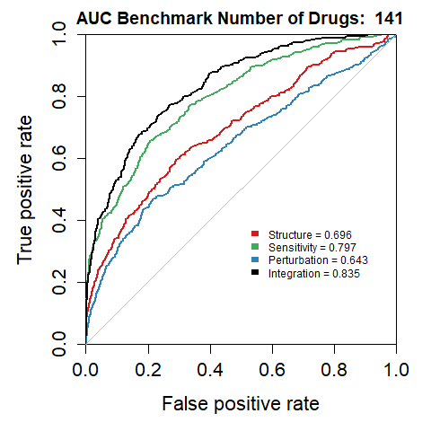

```
[1] "Benchmark obtained"
[1] "Drug pairs obtained"
[1] "Concordance Index computed"
c.indices values from each layer vs. the benchmark:
strcCindex: 0.6964124
sensCindex: 0.7356899
pertCindex: 0.6428657
integrCindex: 0.7652485
p-vals from the c.index comparison of integration layer vs.
strcPVal: 1.415661e-06
sensPVal: 0.001971151
pertPVal: 2.037507e-16
```

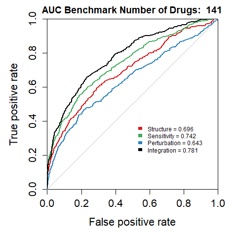

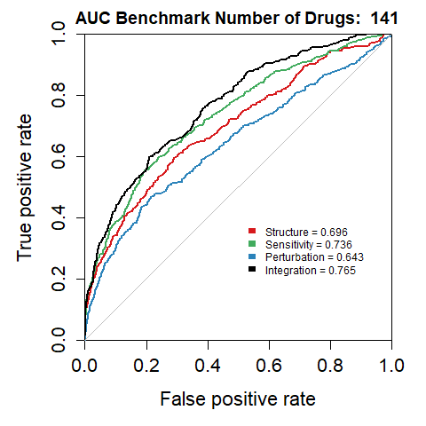

```r
for (i in imputation.sizes) {
    pert.cor <- subsetted.pert.cor[["0"]]
    sens.cor <- subsetted.sens.cor[[as.character(i)]]
    strc.cor <- subsetted.strc.cor[["0"]]


    correlation.matrices <- list(sens=sens.cor, pert=pert.cor, strc=strc.cor)

    augmented.matrices <- CreateAugmentedMatrixSkeletons(names(correlation.matrices), all.drugs)
    augmented.matrices <- ReplaceAugmentedExistingValues(augmented.matrices, correlation.matrices)
    affinity.matrices <- CreateAffinityMatrices(augmented.matrices)
    affinity.matrices <- ReplaceAffinityMatrixValuesFast(affinity.matrices, correlation.matrices, all.drugs)

    integrated <- SNFtool::SNF(affinity.matrices)
    rownames(integrated) <- all.drugs
    colnames(integrated) <- all.drugs

    paste("-----Evaluating Performance on ", i, "imputed drugs-----", sep=" ")

    CompDrugTargetBenchmarkFlexible(common.drugs=common.drugs, gmt.file.name="temp",
                                    strc.aff.mat=affinity.matrices$strc,
                                    sens.aff.mat=affinity.matrices$sens, pert.aff.mat=affinity.matrices$pert,
                                    integration=integrated, luminex.aff.mat=NULL,
                                    imaging.aff.mat=NULL, target.roc.file.name="blessed_roc.pdf",
                                    use.ctrpv2=TRUE, use.clue=FALSE, use.chembl=FALSE,
                                    use.dbank=FALSE, use.dtc=FALSE)
}
```

#### Structure Imputation Effect

Now we loop over the various subsetted structure data versions and evaluate the performance of imputing the drugs that are intentionally missing.

```
[1] "Benchmark obtained"
[1] "Drug pairs obtained"
[1] "Concordance Index computed"
c.indices values from each layer vs. the benchmark:
strcCindex: 0.6964124
sensCindex: 0.8837202
pertCindex: 0.6428657
integrCindex: 0.9200923
p-vals from the c.index comparison of integration layer vs.
strcPVal: 9.025341e-58
sensPVal: 0.0004656051
pertPVal: 1.118052e-69
[1] "Benchmark obtained"
[1] "Drug pairs obtained"
[1] "Concordance Index computed"
c.indices values from each layer vs. the benchmark:
strcCindex: 0.7669731
sensCindex: 0.8837202
pertCindex: 0.6428657
integrCindex: 0.9279854
p-vals from the c.index comparison of integration layer vs.
strcPVal: 5.576812e-38
sensPVal: 2.348278e-05
pertPVal: 6.853544e-74
```

```
[1] "Benchmark obtained"
[1] "Drug pairs obtained"
[1] "Concordance Index computed"
c.indices values from each layer vs. the benchmark:
strcCindex: 0.7784903
sensCindex: 0.8837202
pertCindex: 0.6428657
integrCindex: 0.9073726
p-vals from the c.index comparison of integration layer vs.
strcPVal: 5.597024e-24
sensPVal: 0.02280987
pertPVal: 2.648839e-61
```

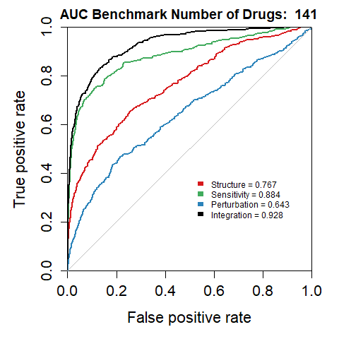

```
[1] "Benchmark obtained"
[1] "Drug pairs obtained"
[1] "Concordance Index computed"
c.indices values from each layer vs. the benchmark:
strcCindex: 0.8274041
sensCindex: 0.8837202
pertCindex: 0.6428657
integrCindex: 0.9134273
p-vals from the c.index comparison of integration layer vs.
strcPVal: 4.048761e-15
sensPVal: 0.004386306
pertPVal: 3.626576e-66
```

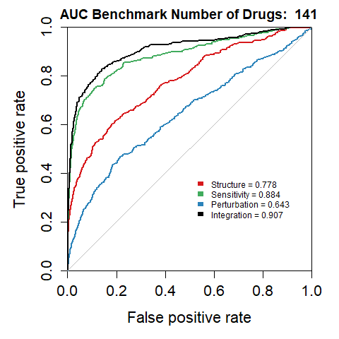

```
[1] "Benchmark obtained"
[1] "Drug pairs obtained"
[1] "Concordance Index computed"
c.indices values from each layer vs. the benchmark:
strcCindex: 0.8745531
sensCindex: 0.8837202
pertCindex: 0.6428657
integrCindex: 0.9108561
p-vals from the c.index comparison of integration layer vs.
strcPVal: 3.04045e-05
sensPVal: 0.007169524
pertPVal: 5.290123e-66
```

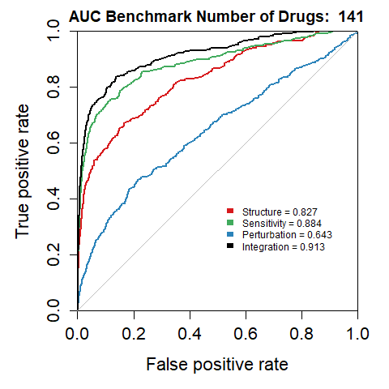

```
[1] "Benchmark obtained"
[1] "Drug pairs obtained"
[1] "Concordance Index computed"
c.indices values from each layer vs. the benchmark:
strcCindex: 0.8767927
sensCindex: 0.8837202
pertCindex: 0.6428657
integrCindex: 0.9053484
p-vals from the c.index comparison of integration layer vs.
strcPVal: 0.0006217733
sensPVal: 0.02652339
pertPVal: 1.590942e-63
```

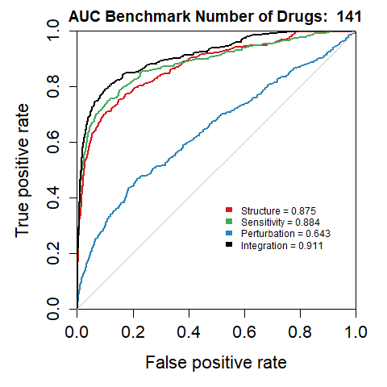

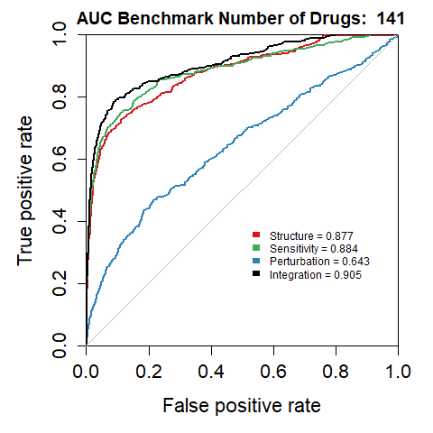

```r
for (i in imputation.sizes) {
    pert.cor <- subsetted.pert.cor[["0"]]
    sens.cor <- subsetted.sens.cor[["0"]]
    strc.cor <- subsetted.strc.cor[[as.character(i)]]

    correlation.matrices <- list(sens=sens.cor, pert=pert.cor, strc=strc.cor)

    augmented.matrices <- CreateAugmentedMatrixSkeletons(names(correlation.matrices), all.drugs)
    augmented.matrices <- ReplaceAugmentedExistingValues(augmented.matrices, correlation.matrices)
    affinity.matrices <- CreateAffinityMatrices(augmented.matrices)
    affinity.matrices <- ReplaceAffinityMatrixValuesFast(affinity.matrices, correlation.matrices, all.drugs)

    integrated <- SNFtool::SNF(affinity.matrices)
    rownames(integrated) <- all.drugs
    colnames(integrated) <- all.drugs

    paste("-----Evaluating Performance on ", i, "imputed drugs-----", sep=" ")

    CompDrugTargetBenchmarkFlexible(common.drugs=common.drugs, gmt.file.name="temp",
                                    strc.aff.mat=affinity.matrices$strc,
                                    sens.aff.mat=affinity.matrices$sens, pert.aff.mat=affinity.matrices$pert,
                                    integration=integrated, luminex.aff.mat=NULL,
                                    imaging.aff.mat=NULL, target.roc.file.name="blessed_roc.pdf",
                                    use.ctrpv2=TRUE, use.clue=FALSE, use.chembl=FALSE,
                                    use.dbank=FALSE, use.dtc=FALSE)
}
```

### Performance on CTRPv2, CHEMBL, and clue.io combined

Now we take a look at the performance on an aggregated drug target dataset consisting of ctrp, chembl, and clue. Hopefully now there will be a negative impact on perturbation if we keep imputing more drugs.

We repeat the process of getting the vector of drugs that will actually be in the benchmark. Again, we are removing drugs only from this set, since only these drugs have an effect on benchmark performance.

```r
benchmark.drugs <- DrugTargetBenchFlexible(common.drugs, gmt_file_name="temp", use.ctrpv2=TRUE,
                        use.clue=TRUE, use.chembl=TRUE, use.dbank=FALSE, use.dtc=FALSE)
benchmark.drugs <- colnames(benchmark.drugs)
```

We again create subsetted versions of the pert layer, each with progressively less drugs in them

```r
set.seed(981)
imputation.sizes <- c(0, 25, 50, 75, 100, 125, 150, 175, 200,length(benchmark.drugs))
subsetted.pert.cor <- list()
subsetted.sens.cor <- list()
subsetted.strc.cor <- list()
for (i in imputation.sizes) {
    drugs.to.remove <- sample(1:length(benchmark.drugs), i)
    drugs.to.remove <- benchmark.drugs[drugs.to.remove]

    temp.pert <- pert.data[, common.drugs]
    temp.pert <- temp.pert[, !(colnames(temp.pert) %in% drugs.to.remove)]
    subsetted.pert.cor[[as.character(i)]] <- cor(temp.pert, method="pearson", use="pairwise.complete.obs")

    temp.sens <- sens.data[common.drugs, common.drugs]
    temp.sens <- temp.sens[!(rownames(temp.sens) %in% drugs.to.remove), !(colnames(temp.sens) %in% drugs.to.remove)]
    subsetted.sens.cor[[as.character(i)]] <- temp.sens

    temp.strc <- strc.data[common.drugs]
    temp.strc <- temp.strc[!(names(temp.strc) %in% drugs.to.remove)]
    temp.names <- names(temp.strc)
    temp.strc <- fingerprint::fp.sim.matrix(temp.strc, method = "tanimoto")
    colnames(temp.strc) <- temp.names
    rownames(temp.strc) <- temp.names
    subsetted.strc.cor[[as.character(i)]] <- temp.strc
}
```

#### Perturbation Imputation Effect

Now we loop over the various subsetted perturbation data versions and evaluate the performance of imputing the drugs that are intentionally missing.

```
[1] "Benchmark obtained"
[1] "Drug pairs obtained"
[1] "Concordance Index computed"
c.indices values from each layer vs. the benchmark:
strcCindex: 0.6864531
sensCindex: 0.725943
pertCindex: 0.6171994
integrCindex: 0.8172772
p-vals from the c.index comparison of integration layer vs.
strcPVal: 5.199429e-49
sensPVal: 9.867461e-19
pertPVal: 4.382483e-90
[1] "Benchmark obtained"
[1] "Drug pairs obtained"
[1] "Concordance Index computed"
c.indices values from each layer vs. the benchmark:
strcCindex: 0.6864531
sensCindex: 0.725943
pertCindex: 0.6312985
integrCindex: 0.8221467
p-vals from the c.index comparison of integration layer vs.
strcPVal: 8.142251e-54
sensPVal: 5.341918e-21
pertPVal: 2.355921e-80
```

```
[1] "Benchmark obtained"
[1] "Drug pairs obtained"
[1] "Concordance Index computed"
c.indices values from each layer vs. the benchmark:
strcCindex: 0.6864531
sensCindex: 0.725943
pertCindex: 0.6683117
integrCindex: 0.8275477
p-vals from the c.index comparison of integration layer vs.
strcPVal: 1.918735e-57
sensPVal: 1.175115e-24
pertPVal: 2.030727e-59
```

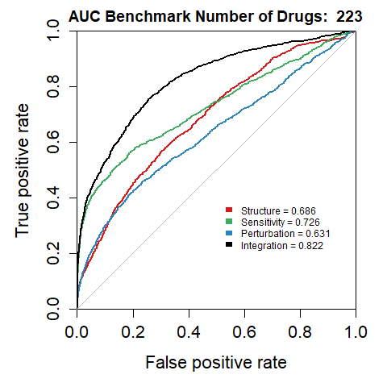

```
[1] "Benchmark obtained"
[1] "Drug pairs obtained"
[1] "Concordance Index computed"
c.indices values from each layer vs. the benchmark:
strcCindex: 0.6864531
sensCindex: 0.725943
pertCindex: 0.6953721
integrCindex: 0.8274977
p-vals from the c.index comparison of integration layer vs.
strcPVal: 5.181801e-57
sensPVal: 1.126272e-24
pertPVal: 4.509418e-43
```

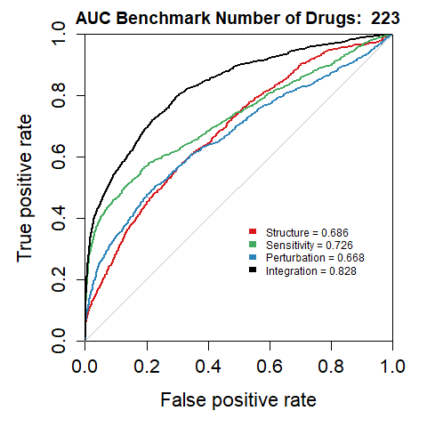

```
[1] "Benchmark obtained"
[1] "Drug pairs obtained"
[1] "Concordance Index computed"
c.indices values from each layer vs. the benchmark:
strcCindex: 0.6864531
sensCindex: 0.725943
pertCindex: 0.6994404
integrCindex: 0.822605
p-vals from the c.index comparison of integration layer vs.
strcPVal: 2.136433e-53
sensPVal: 1.442358e-22
pertPVal: 3.231143e-41
```

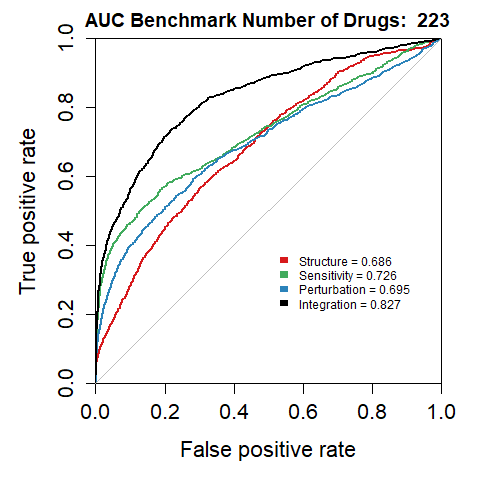

```
[1] "Benchmark obtained"
[1] "Drug pairs obtained"
[1] "Concordance Index computed"
c.indices values from each layer vs. the benchmark:
strcCindex: 0.6864531
sensCindex: 0.725943
pertCindex: 0.7444071
integrCindex: 0.8243661
p-vals from the c.index comparison of integration layer vs.
strcPVal: 2.119703e-54
sensPVal: 2.084185e-23
pertPVal: 6.349618e-23
```

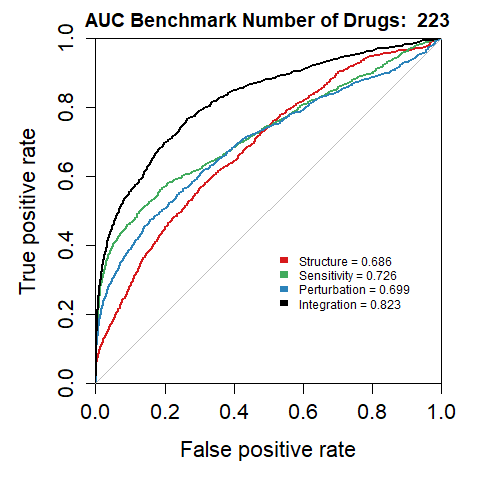

```
[1] "Benchmark obtained"
[1] "Drug pairs obtained"
[1] "Concordance Index computed"
c.indices values from each layer vs. the benchmark:
strcCindex: 0.6864531
sensCindex: 0.725943
pertCindex: 0.7540357
integrCindex: 0.8234229
p-vals from the c.index comparison of integration layer vs.
strcPVal: 3.020902e-52
sensPVal: 1.241509e-23
pertPVal: 2.056754e-18
```

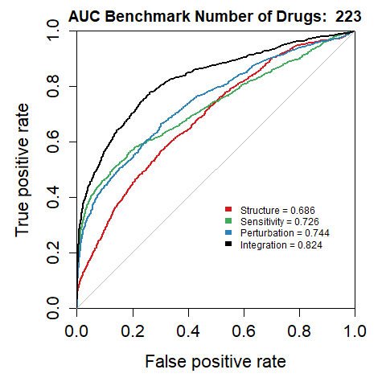

```
[1] "Benchmark obtained"
[1] "Drug pairs obtained"
[1] "Concordance Index computed"
c.indices values from each layer vs. the benchmark:
strcCindex: 0.6864531
sensCindex: 0.725943
pertCindex: 0.7692007
integrCindex: 0.8241108
p-vals from the c.index comparison of integration layer vs.
strcPVal: 2.674015e-55
sensPVal: 6.363735e-24
pertPVal: 1.837041e-14
```

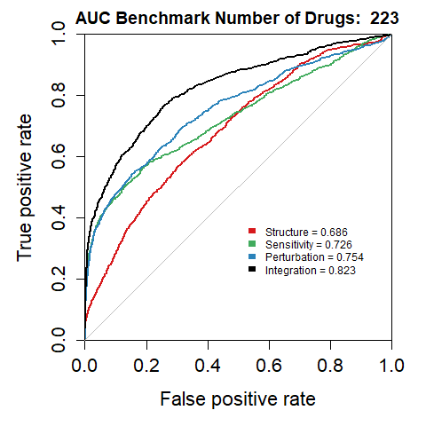

```
[1] "Benchmark obtained"
[1] "Drug pairs obtained"
[1] "Concordance Index computed"
c.indices values from each layer vs. the benchmark:
strcCindex: 0.6864531
sensCindex: 0.725943
pertCindex: 0.7729876
integrCindex: 0.8273338
p-vals from the c.index comparison of integration layer vs.
strcPVal: 1.296584e-58
sensPVal: 6.135374e-26
pertPVal: 3.838333e-15
```

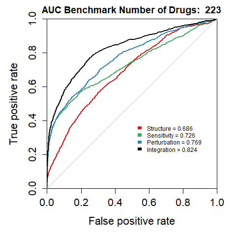

```
[1] "Benchmark obtained"
[1] "Drug pairs obtained"
[1] "Concordance Index computed"
c.indices values from each layer vs. the benchmark:
strcCindex: 0.6864531
sensCindex: 0.725943
pertCindex: 0.7740129
integrCindex: 0.8281888
p-vals from the c.index comparison of integration layer vs.
strcPVal: 1.181061e-59
sensPVal: 2.383027e-26
pertPVal: 2.498266e-15
```

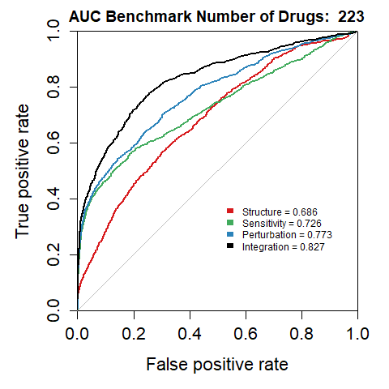

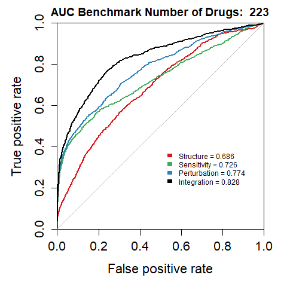

```r
for (i in imputation.sizes) {
    pert.cor <- subsetted.pert.cor[[as.character(i)]]
    sens.cor <- subsetted.sens.cor[["0"]]
    strc.cor <- subsetted.strc.cor[["0"]]

    correlation.matrices <- list(sens=sens.cor, pert=pert.cor, strc=strc.cor)

    augmented.matrices <- CreateAugmentedMatrixSkeletons(names(correlation.matrices), all.drugs)
    augmented.matrices <- ReplaceAugmentedExistingValues(augmented.matrices, correlation.matrices)
    affinity.matrices <- CreateAffinityMatrices(augmented.matrices)
    affinity.matrices <- ReplaceAffinityMatrixValuesFast(affinity.matrices, correlation.matrices, all.drugs)

    integrated <- SNFtool::SNF(affinity.matrices)
    rownames(integrated) <- all.drugs
    colnames(integrated) <- all.drugs

    paste("-----Evaluating Performance on ", i, "imputed drugs-----", sep=" ")

    CompDrugTargetBenchmarkFlexible(common.drugs=common.drugs, gmt.file.name="temp",
                                    strc.aff.mat=affinity.matrices$strc,
                                    sens.aff.mat=affinity.matrices$sens, pert.aff.mat=affinity.matrices$pert,
                                    integration=integrated, luminex.aff.mat=NULL,
                                    imaging.aff.mat=NULL, target.roc.file.name="blessed_roc.pdf",
                                    use.ctrpv2=TRUE, use.clue=TRUE, use.chembl=TRUE,
                                    use.dbank=FALSE, use.dtc=FALSE)
}
```